# Assignment2_JianghongMan

Jianghong Man

4/10/2021

0. Set the working directory and load the libary

```r
setwd('~/Desktop/Time_Series/2/')
library(fpp)
```

1. Load the visitors.rda dataset, make a time plot of your data and describe the main features of the series.

```r
# Load the data
#data <- window(visitors)
#head(data)

load(file = "visitors.rda")
data <- ts(visitors$Arrivals, start = c(1981,1), frequency = 4)
```

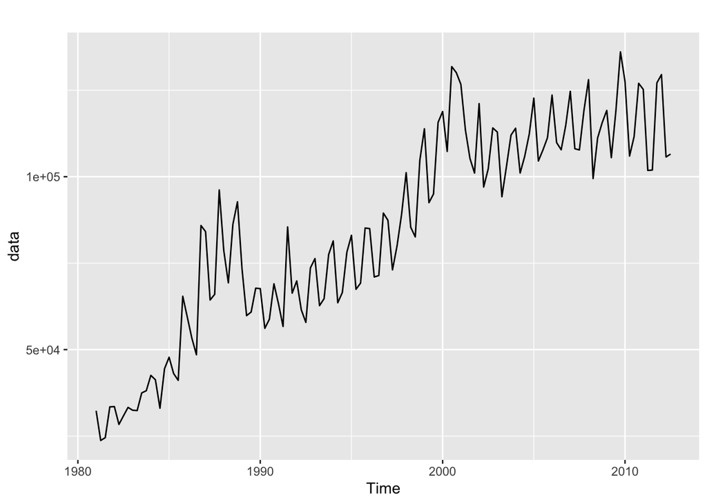

```r
# Make a time plot
autoplot(data)
```

```r
summary(data)
```

```
##    Min. 1st Qu.  Median    Mean 3rd Qu.    Max.
##   23721   63950   85878   84849  108977  136094
```

```r
head(data)
```

```
##       Qtr1  Qtr2  Qtr3  Qtr4
## 1981 32316 23721 24533 33438
## 1982 33527 28366
```

Based on the time series plot, there is a positive trend and a strong seasonality in the data. There is also a small cyclic pattern for every 10 years: from 1981 to 1989, from 1990 to 2000, and from 2000 to the end date of the total data. The increasing amplitude of three time span is different from each other.

2. What is the appropriate Holt-Winters method for this data set (multiplicative / additive)? why?

Based on the time series plot, we can see that the amplitude of seasonal trend increases with the increasing trend. Thus, multiplicative is the appropriate HW method for this data set.

```r
fit_hw <- hw(data, h = 16, seasonal = "mult")
```

```r
fit_hw
```

```
##         Point Forecast     Lo 80    Hi 80    Lo 95    Hi 95
## 2012 Q4       123862.7 107696.49 140028.9 99138.61 148586.8
## 2013 Q1       125806.2 107782.01 143830.4 98240.58 153371.8
## 2013 Q2       106438.3  89903.90 122972.6 81151.14 131725.4
## 2013 Q3       111359.4  92774.92 129943.8 82936.91 139781.8
## 2013 Q4       125986.0 103558.59 148413.3 91686.26 160285.6
## 2014 Q1       127953.5 103796.71 152110.4 91008.85 164898.2
## 2014 Q2       108247.3  86674.94 129819.7 75255.21 141239.4
## 2014 Q3       113244.0  89514.57 136973.5 76952.95 149535.1
## 2014 Q4       128109.2  99976.57 156241.8 85084.06 171134.3
## 2015 Q1       130100.9 100245.72 159956.1 84441.34 175760.4
## 2015 Q2       110056.4  83730.22 136382.5 69794.01 150318.7
## 2015 Q3       115128.7  86484.09 143773.4 71320.54 158936.9
## 2015 Q4       130232.4  96594.01 163870.9 78786.90 181678.0
## 2016 Q1       132248.3  96847.61 167648.9 78107.65 186388.9
## 2016 Q2       111865.4  80880.40 142850.4 64477.93 159252.9
## 2016 Q3       117013.4  83522.95 150503.9 65794.18 168232.6
```

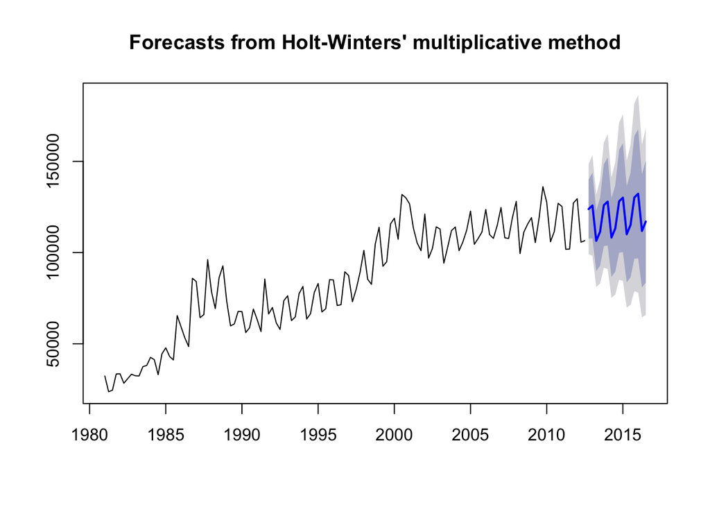

```r
plot(fit_hw)
```

3. Use the hw() function to forecast the next 16 quarters using Holt-Winters’ methods. Experiment with the following methods

```r
# Linear trend with additive seasonality
fit1 <- hw(data, h = 16, seasonal = "additive")
fit1
```

```
##         Point Forecast     Lo 80    Hi 80     Lo 95    Hi 95
## 2012 Q4       121407.0 111421.09 131393.0 106134.85 136679.2
## 2013 Q1       122651.1 111548.98 133753.2 105671.88 139630.3
## 2013 Q2       108818.3  96702.04 120934.6  90288.07 127348.6
## 2013 Q3       112744.7  99692.48 125797.0  92783.02 132706.5
## 2013 Q4       124168.5 110242.36 138094.7 102870.29 145466.8
## 2014 Q1       125412.6 110664.21 140161.0 102856.89 147968.3
## 2014 Q2       111579.8  96052.40 127107.3  87832.67 135327.0
## 2014 Q3       115506.3  99236.73 131775.8  90624.16 140388.4
## 2014 Q4       126930.1 109950.27 143909.8 100961.71 152898.4
## 2015 Q1       128174.1 110512.62 145835.6 101163.18 155185.1
## 2015 Q2       114341.4  96023.23 132659.5  86326.19 142356.5
## 2015 Q3       118267.8  99315.49 137220.1  89282.76 147252.8
## 2015 Q4       129691.6 110125.18 149258.0  99767.36 159615.8
## 2016 Q1       130935.6 110773.85 151097.4 100100.84 161770.5
## 2016 Q2       117102.9  96362.53 137843.2  85383.25 148822.5
## 2016 Q3       121029.3  99725.87 142332.7  88448.51 153610.1
```

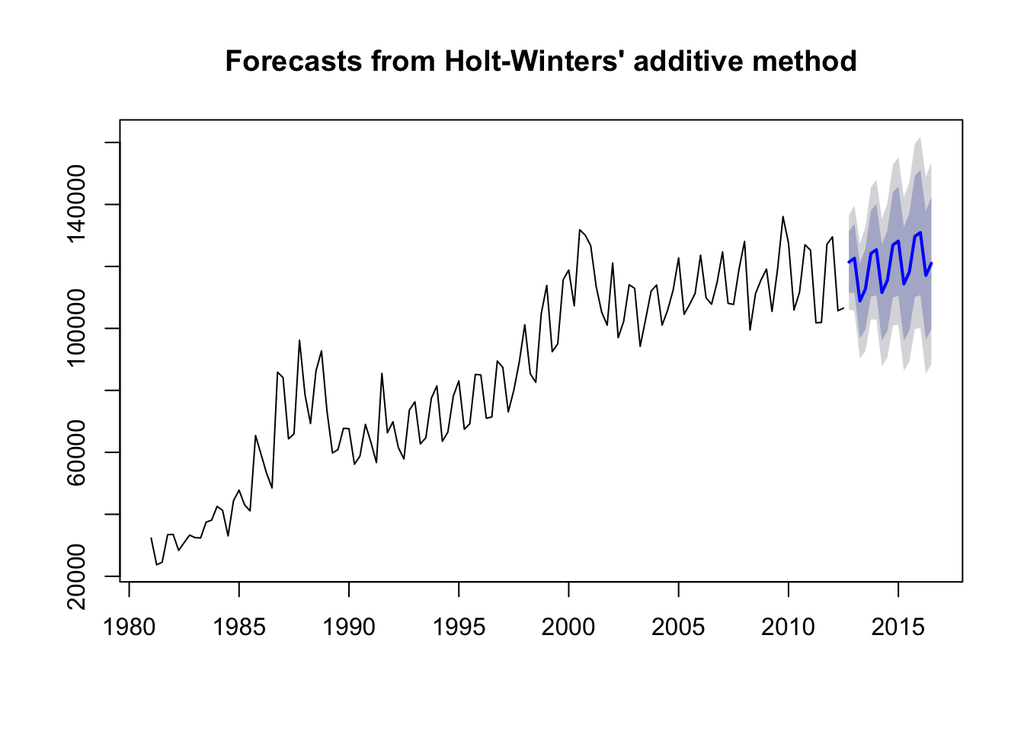

```r
plot(fit1)
```

```r
# Linear trend with multiplicative seasonality
fit2 <- hw(data, h = 16, seasonal = "multiplicative")
fit2
```

```
##         Point Forecast     Lo 80    Hi 80    Lo 95    Hi 95
## 2012 Q4       123862.7 107696.49 140028.9 99138.61 148586.8
## 2013 Q1       125806.2 107782.01 143830.4 98240.58 153371.8
## 2013 Q2       106438.3  89903.90 122972.6 81151.14 131725.4
## 2013 Q3       111359.4  92774.92 129943.8 82936.91 139781.8
## 2013 Q4       125986.0 103558.59 148413.3 91686.26 160285.6
## 2014 Q1       127953.5 103796.71 152110.4 91008.85 164898.2
## 2014 Q2       108247.3  86674.94 129819.7 75255.21 141239.4
## 2014 Q3       113244.0  89514.57 136973.5 76952.95 149535.1
## 2014 Q4       128109.2  99976.57 156241.8 85084.06 171134.3
## 2015 Q1       130100.9 100245.72 159956.1 84441.34 175760.4
## 2015 Q2       110056.4  83730.22 136382.5 69794.01 150318.7
## 2015 Q3       115128.7  86484.09 143773.4 71320.54 158936.9
## 2015 Q4       130232.4  96594.01 163870.9 78786.90 181678.0
## 2016 Q1       132248.3  96847.61 167648.9 78107.65 186388.9
## 2016 Q2       111865.4  80880.40 142850.4 64477.93 159252.9
## 2016 Q3       117013.4  83522.95 150503.9 65794.18 168232.6
```

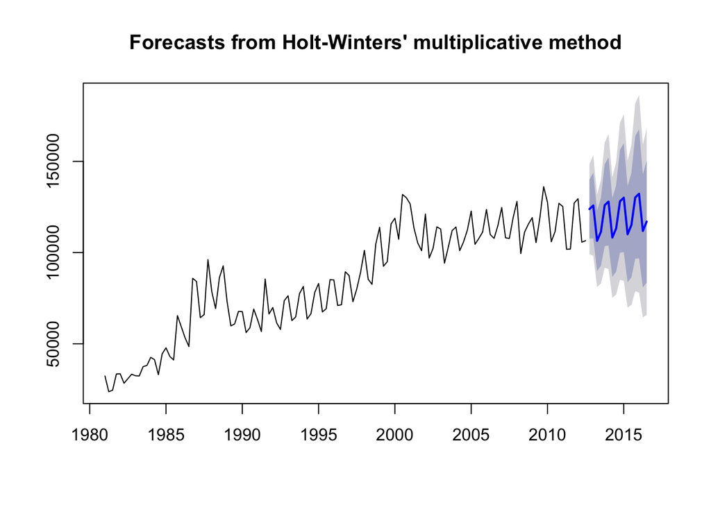

```r
plot(fit2)
```

```r
# Linear trend with additive seasonality and damping
fit3 <- hw(data, h = 16, seasonal = "additive", damped = TRUE)
fit3
```

```
##         Point Forecast     Lo 80    Hi 80     Lo 95    Hi 95
## 2012 Q4       121033.7 110993.04 131074.4 105677.84 136389.6
## 2013 Q1       123116.0 112020.39 134211.7 106146.71 140085.4
## 2013 Q2       105058.3  92999.21 117117.4  86615.52 123501.0
## 2013 Q3       109824.8  96873.38 122776.1  90017.34 129632.2
## 2013 Q4       121581.7 107515.11 135648.4 100068.68 143094.8
## 2014 Q1       123653.1 108813.84 138492.4 100958.40 146347.8
## 2014 Q2       105584.6  90010.70 121158.5  81766.38 129402.8
## 2014 Q3       110340.5  94064.89 126616.2  85449.08 135232.0
## 2014 Q4       122087.2 104909.68 139264.8  95816.44 148358.0
## 2015 Q1       124148.5 106331.79 141965.2  96900.21 151396.8
## 2015 Q2       106070.1  87636.16 124504.0  77877.84 134262.3
## 2015 Q3       110816.3  91784.99 129847.6  81710.42 139922.2
## 2015 Q4       122553.5 102744.43 142362.5  92258.17 152848.7
## 2016 Q1       124605.4 104238.90 144971.9  93457.53 155753.3
## 2016 Q2       106517.8  85608.56 127427.1  74539.86 138495.8
## 2016 Q3       111255.1  89816.63 132693.6  78467.78 144042.5
```

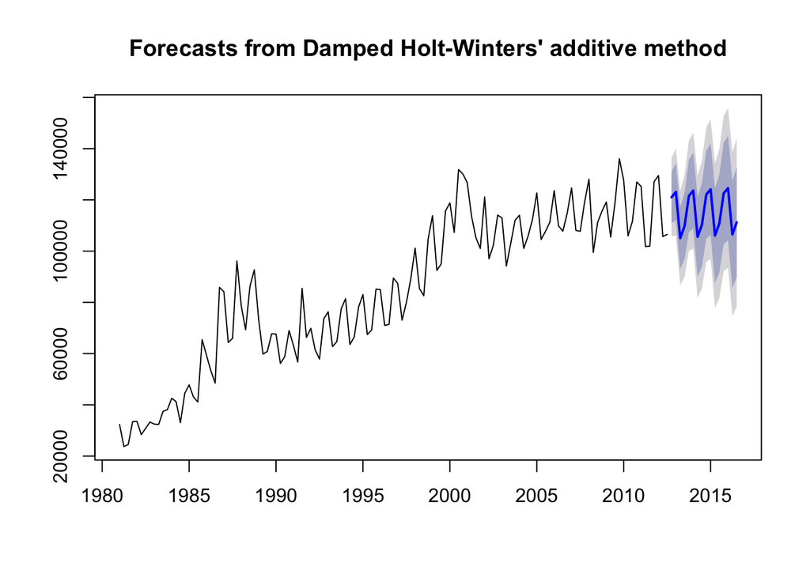

```r
plot(fit3)
```

```r
# Linear trend with multiplicative seasonality and damping
fit4 <- hw(data, h = 16, seasonal = "multiplicative", damped = TRUE)
fit4
```

```
##         Point Forecast     Lo 80    Hi 80    Lo 95    Hi 95
## 2012 Q4       122225.2 106033.32 138417.1 97461.86 146988.5
## 2013 Q1       123798.8 105276.90 142320.8 95471.97 152125.7
## 2013 Q2       105187.4  87816.96 122557.8 78621.62 131753.1
## 2013 Q3       109171.5  89578.75 128764.3 79206.97 139136.1
## 2013 Q4       122829.1  99138.55 146519.6 86597.54 159060.7
## 2014 Q1       124397.5  98830.37 149964.7 85295.93 163499.2
## 2014 Q2       105685.3  82691.88 128678.6 70519.92 140850.6
## 2014 Q3       109677.3  84552.31 134802.3 71251.94 148102.7
## 2014 Q4       123386.1  93754.23 153018.0 78068.05 168704.2
## 2015 Q1       124949.8  93607.44 156292.1 77015.81 172883.7
## 2015 Q2       106144.5  78421.35 133867.7 63745.60 148543.4
## 2015 Q3       110143.9  80270.02 140017.7 64455.77 155832.0
## 2015 Q4       123899.9  89083.75 158716.1 70653.18 177146.7
## 2016 Q1       125459.1  89009.06 161909.2 69713.57 181204.7
## 2016 Q2       106568.1  74614.21 138522.0 57698.83 155437.4
## 2016 Q3       110574.2  76411.57 144736.8 58326.96 162821.4
```

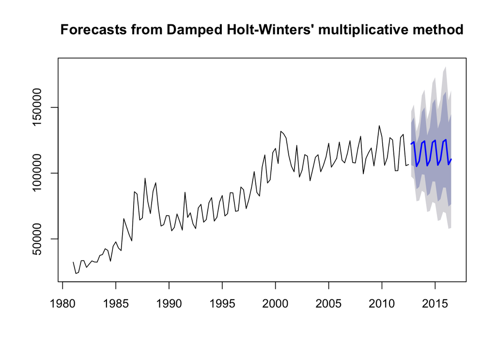

```r
plot(fit4)
```

```r
# Also, use the snaive() function to forecast the next 16 quarters using Seasonal naïve method.
fit_snaive <- snaive(data, h=16)
fit_snaive
```

```
##         Point Forecast     Lo 80    Hi 80     Lo 95    Hi 95
## 2012 Q4         127150 113951.32 140348.7 106964.36 147335.6
## 2013 Q1         129520 116321.32 142718.7 109334.36 149705.6
## 2013 Q2         105700  92501.32 118898.7  85514.36 125885.6
## 2013 Q3         106540  93341.32 119738.7  86354.36 126725.6
## 2013 Q4         127150 108484.25 145815.8  98603.19 155696.8
## 2014 Q1         129520 110854.25 148185.8 100973.19 158066.8
## 2014 Q2         105700  87034.25 124365.8  77153.19 134246.8
## 2014 Q3         106540  87874.25 125205.8  77993.19 135086.8
## 2014 Q4         127150 104289.22 150010.8  92187.45 162112.6
## 2015 Q1         129520 106659.22 152380.8  94557.45 164482.6
## 2015 Q2         105700  82839.22 128560.8  70737.45 140662.6
## 2015 Q3         106540  83679.22 129400.8  71577.45 141502.6
## 2015 Q4         127150 100752.64 153547.4  86778.72 167521.3
## 2016 Q1         129520 103122.64 155917.4  89148.72 169891.3
## 2016 Q2         105700  79302.64 132097.4  65328.72 146071.3
## 2016 Q3         106540  80142.64 132937.4  66168.72 146911.3
```

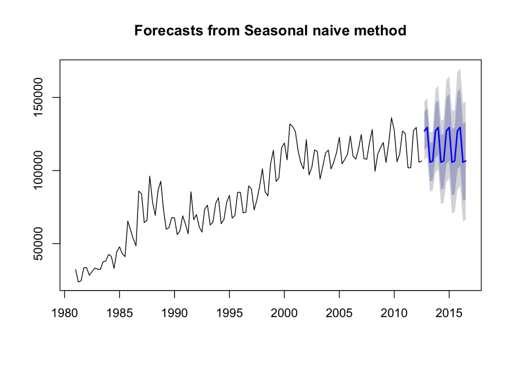

```r
plot(fit_snaive)
```

5. Use the accuracy() function to compare the Root-Mean-Square-Error (RMSE) values of the forecasts from the various methods. Which do you prefer and why?

```r
accuracy(fit1) # RMSE = 7542.656
```

```
##                     ME     RMSE      MAE        MPE     MAPE      MASE
## Training set -41.56992 7542.656 5478.829 -0.3174557 7.439141 0.7423397
##                    ACF1
## Training set 0.02191009
```

```r
accuracy(fit2) # RMSE = 7550.956
```

```
##                     ME     RMSE      MAE       MPE     MAPE      MASE
## Training set -774.8691 7550.956 5444.033 -1.701107 6.947776 0.7376251
##                    ACF1
## Training set 0.08109975
```

```r
accuracy(fit3) # RMSE = 7552.064
```

```
##                    ME     RMSE      MAE        MPE     MAPE     MASE       ACF1
## Training set 18.41066 7552.064 5551.979 -0.8327106 7.471211 0.752251 0.03207652
```

```r
accuracy(fit4) # RMSE = 7460.002
```

```
##                     ME     RMSE     MAE        MPE     MAPE      MASE
## Training set -1.834419 7460.002 5363.22 -0.9701216 6.852661 0.7266756
##                      ACF1
## Training set -0.001971966
```

```r
accuracy(fit_snaive) # RMSE = 10298.98
```

```
##                    ME     RMSE      MAE      MPE     MAPE MASE      ACF1
## Training set 2885.382 10298.98 7380.488 3.728117 9.396353    1 0.4528293
```

5. Use the checkresiduals() function to check that the residuals from the best model look like white noise and provide a summary of the model’s smoothing parameters using the summary() function.

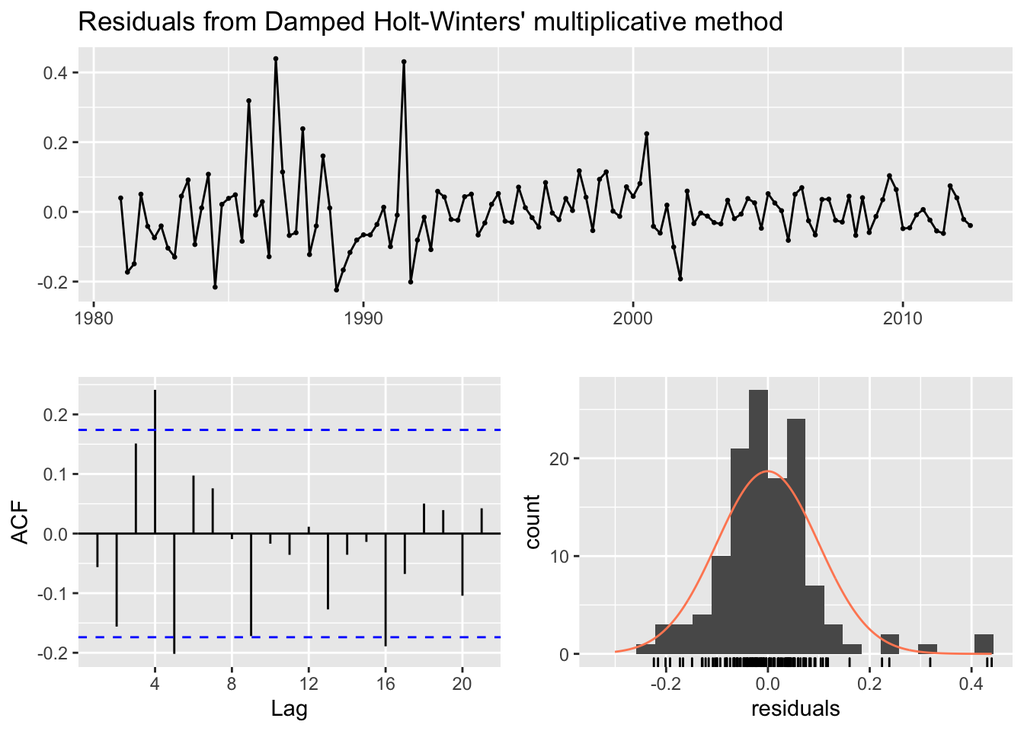

```
##
##  Ljung-Box test
##
## data:  Residuals from Damped Holt-Winters' multiplicative method
## Q* = 26.266, df = 3, p-value = 8.388e-06
##
## Model df: 9.   Total lags used: 12
```

```r
checkresiduals(fit4)
```

```r
summary(fit4)
```

```
##
## Forecast method: Damped Holt-Winters' multiplicative method
##
## Model Information:
## Damped Holt-Winters' multiplicative method
##
## Call:
##  hw(y = data, h = 16, seasonal = "multiplicative", damped = TRUE)
##
##   Smoothing parameters:
##     alpha = 0.52
##     beta  = 0.0027
##     gamma = 1e-04
##     phi   = 0.98
##
##   Initial states:
##     l = 26914.2591
##     b = 2002.8599
##     s = 1.0638 0.9467 0.9133 1.0762
##
##   sigma:  0.1034
##
##      AIC     AICc      BIC
## 2913.642 2915.538 2942.084
##
## Error measures:
##                     ME     RMSE     MAE        MPE     MAPE      MASE
## Training set -1.834419 7460.002 5363.22 -0.9701216 6.852661 0.7266756
##                      ACF1
## Training set -0.001971966
##
## Forecasts:
##         Point Forecast     Lo 80    Hi 80    Lo 95    Hi 95
## 2012 Q4       122225.2 106033.32 138417.1 97461.86 146988.5
## 2013 Q1       123798.8 105276.90 142320.8 95471.97 152125.7
## 2013 Q2       105187.4  87816.96 122557.8 78621.62 131753.1
## 2013 Q3       109171.5  89578.75 128764.3 79206.97 139136.1
## 2013 Q4       122829.1  99138.55 146519.6 86597.54 159060.7
## 2014 Q1       124397.5  98830.37 149964.7 85295.93 163499.2
## 2014 Q2       105685.3  82691.88 128678.6 70519.92 140850.6
## 2014 Q3       109677.3  84552.31 134802.3 71251.94 148102.7
## 2014 Q4       123386.1  93754.23 153018.0 78068.05 168704.2
## 2015 Q1       124949.8  93607.44 156292.1 77015.81 172883.7
## 2015 Q2       106144.5  78421.35 133867.7 63745.60 148543.4
## 2015 Q3       110143.9  80270.02 140017.7 64455.77 155832.0
## 2015 Q4       123899.9  89083.75 158716.1 70653.18 177146.7
## 2016 Q1       125459.1  89009.06 161909.2 69713.57 181204.7
## 2016 Q2       106568.1  74614.21 138522.0 57698.83 155437.4
## 2016 Q3       110574.2  76411.57 144736.8 58326.96 162821.4
```